# Course Project - Practical Machine Learning

PowLook Yap

August 23, 2015

## Project Overview

This project looks at the activities of a group of users as they use their wearable devices to perform a set of activities. The purpose of this exercise will be to learn from the activities they have done and therefore to predict what activities they are doing given a set of data. The information about this experiment and dataset are available from the following website : http://groupware.les.inf.puc-rio.br/har (see the section on the Weight Lifting Exercise Dataset).

## Data download and Preparation

The dataset (2 sets) are downloaded from the site as given below. They are then read into R as training and testing sets. The structure of both the datasets are also displayed to check for any peculiarities.

```r
suppressWarnings(library(caret))
suppressWarnings(library(dplyr))
suppressWarnings(library(randomForest))
```

```r
setwd("D:/Coursera - Data Science/8. Practical Machine Learning/Assignments")
## Reading of dataset
setwd("D:/Coursera - Data Science/8. Practical Machine Learning/Assignments")
## trainURL <- "https://d396qusza40orc.cloudfront.net/predmachlearn/pml-training.csv"
##download.file(trainURL,"pml-training.csv")
training <- read.csv("pml-training.csv")
##testURL  <- "https://d396qusza40orc.cloudfront.net/predmachlearn/pml-testing.csv"
##download.file(testURL,"pml-testing.csv")
predict <- read.csv("pml-testing.csv")
str(training)
```

```
## 'data.frame':    19622 obs. of  160 variables:
##  $ X                       : int  1 2 3 4 5 6 7 8 9 10 ...
##  $ user_name               : Factor w/ 6 levels "adelmo","carlitos",..: 2 2 2 2 2 2 2 2 2 2 ...
##  $ raw_timestamp_part_1    : int  1323084231 1323084231 1323084231 1323084232 1323084232 1323084232 1323084232 1323084232 1323084232 1323084232 ...
##  $ raw_timestamp_part_2    : int  788290 808298 820366 120339 196328 304277 368296 440390 484323 484434 ...
##  $ cvtd_timestamp          : Factor w/ 20 levels "2/12/2011 13:32",..: 15 15 15 15 15 15 15 15 15 15 ...
##  $ new_window              : Factor w/ 2 levels "no","yes": 1 1 1 1 1 1 1 1 1 1 ...
##  $ num_window              : int  11 11 11 12 12 12 12 12 12 12 ...
##  $ roll_belt               : num  1.41 1.41 1.42 1.48 1.48 1.45 1.42 1.42 1.43 1.45 ...
##  $ pitch_belt              : num  8.07 8.07 8.07 8.05 8.07 8.06 8.09 8.13 8.16 8.17 ...
##  $ yaw_belt                : num  -94.4 -94.4 -94.4 -94.4 -94.4 -94.4 -94.4 -94.4 -94.4 -94.4 ...
##  $ total_accel_belt        : int  3 3 3 3 3 3 3 3 3 3 ...
##  $ kurtosis_roll_belt      : Factor w/ 397 levels "","-0.01685",..: 1 1 1 1 1 1 1 1 1 1 ...
##  $ kurtosis_picth_belt     : Factor w/ 317 levels "","-0.021887",..: 1 1 1 1 1 1 1 1 1 1 ...
##  $ kurtosis_yaw_belt       : Factor w/ 2 levels "","#DIV/0!": 1 1 1 1 1 1 1 1 1 1 ...
```

[output cut: 86 more lines]

```r
str(predict)
```

```
## 'data.frame':    20 obs. of  160 variables:
##  $ X                       : int  1 2 3 4 5 6 7 8 9 10 ...
##  $ user_name               : Factor w/ 6 levels "adelmo","carlitos",..: 6 5 5 1 4 5 5 5 2 3 ...
##  $ raw_timestamp_part_1    : int  1323095002 1322673067 1322673075 1322832789 1322489635 1322673149 1322673128 1322673076 1323084240 1322837822 ...
##  $ raw_timestamp_part_2    : int  868349 778725 342967 560311 814776 510661 766645 54671 916313 384285 ...
##  $ cvtd_timestamp          : Factor w/ 11 levels "2/12/2011 13:33",..: 11 7 7 1 3 8 8 7 9 2 ...
##  $ new_window              : Factor w/ 1 level "no": 1 1 1 1 1 1 1 1 1 1 ...
##  $ num_window              : int  74 431 439 194 235 504 485 440 323 664 ...
##  $ roll_belt               : num  123 1.02 0.87 125 1.35 -5.92 1.2 0.43 0.93 114 ...
##  $ pitch_belt              : num  27 4.87 1.82 -41.6 3.33 1.59 4.44 4.15 6.72 22.4 ...
##  $ yaw_belt                : num  -4.75 -88.9 -88.5 162 -88.6 -87.7 -87.3 -88.5 -93.7 -13.1 ...
##  $ total_accel_belt        : int  20 4 5 17 3 4 4 4 4 18 ...
##  $ kurtosis_roll_belt      : logi  NA NA NA NA NA NA ...
##  $ kurtosis_picth_belt     : logi  NA NA NA NA NA NA ...
##  $ kurtosis_yaw_belt       : logi  NA NA NA NA NA NA ...
```

[output cut: 86 more lines]

From the inspection of the datasets, the following observations were made 1. Both datasets have 160 variables 2. Training dataset (19622 rows) is the training set by which we will need to use to train the model. The outcome,“classe” is the last variable 3. Predict dataset (20 rows) is one which we will use to predict the outcome. 4. The *predict* dataset has many rows which has NA data. As such variables are not available for machine learning, we will use the *predict* dataset to remove all the non-relevant columns and apply that to the training dataset as well. In this way both datasets will have the same set of variables.

## Data Cleaning and Exploratory Analysis

The following chunk of code serves to check for NA fields in all of testing dataset. It will remove all those columns that has NA present. The operations also remove the first 7 columns of the dataset as these are timing and descriptive variables or termed as “book-keeping” columns not related to the question at hand.

```r
x <- is.na(predict)              ##  Checking for existence of NA
y <- as.logical(apply(x,2,sum))    ##  Count No of NAs in a column
training1 <- training[,!y]         ##  Remove all columns with NAs present
training1 <- training1[,-1:-7]     ##  Remove the first 7 column of the training dataset
predictSP <- predict[,!y]          ##  Remove all columns with NAs present
predictSP <- predictSP[,-1:-7]     ##  Remove the first 7 column of the predict dataset
```

After remove the non-relevant columns, it is noted that we have reduced the number of vaiables from 160 to 53 (including the outcome). This will make our machine learning process much faster

## Partition the training set to training and tune

Next we partition the training set to 2 subsets in the ration of 70/30. One for the training and another to test that the model is accurate before we apply it for the prediction in the predict set

```r
set.seed(1960)
trainIndex <- createDataPartition(training1$classe, p = 0.70,list=FALSE)
trainSP <-  training1[trainIndex,]
testSP  <-  training1[-trainIndex,]
```

## Machine Learning

#### Using Random Forest

Random Forest is tried first as it is one of the best machine learning algorithms. However the caret package is not used as the training time is too long and the amount of resources (memories) is too much for my computer of 2GB RAM. Instead I opted to use the standard randomForest function which is much faster and can accomodate my limited resources. A forest of 400 trees and 4 variables is first used.

```r
rf <- randomForest(classe~.,data=trainSP,mtry=4,ntree=400,importance=TRUE)
confusionMatrix(testSP$classe,predict(rf,testSP))
```

```
## Confusion Matrix and Statistics
##
##           Reference
## Prediction    A    B    C    D    E
##          A 1671    3    0    0    0
##          B    7 1128    4    0    0
##          C    0    5 1017    4    0
##          D    0    0    4  960    0
##          E    0    0    3    2 1077
##
## Overall Statistics
##
##                Accuracy : 0.9946
##                  95% CI : (0.9923, 0.9963)
##     No Information Rate : 0.2851
##     P-Value [Acc > NIR] : < 2.2e-16
##
##                   Kappa : 0.9931
##  Mcnemar's Test P-Value : NA
##
## Statistics by Class:
##
##                      Class: A Class: B Class: C Class: D Class: E
## Sensitivity            0.9958   0.9930   0.9893   0.9938   1.0000
## Specificity            0.9993   0.9977   0.9981   0.9992   0.9990
## Pos Pred Value         0.9982   0.9903   0.9912   0.9959   0.9954
## Neg Pred Value         0.9983   0.9983   0.9977   0.9988   1.0000
## Prevalence             0.2851   0.1930   0.1747   0.1641   0.1830
## Detection Rate         0.2839   0.1917   0.1728   0.1631   0.1830
## Detection Prevalence   0.2845   0.1935   0.1743   0.1638   0.1839
## Balanced Accuracy      0.9976   0.9953   0.9937   0.9965   0.9995
```

#### Using Decision Tress (rpart)

I have also tried to use the Decision Trees algorithm just to compare the 2 models formed.

```r
glmFit <- train(classe~.,method="rpart",data=trainSP)
confusionMatrix(testSP$classe,predict(glmFit,testSP))
```

```
## Confusion Matrix and Statistics
##
##           Reference
## Prediction    A    B    C    D    E
##          A 1528   26  115    0    5
##          B  478  384  277    0    0
##          C  482   37  507    0    0
##          D  433  177  354    0    0
##          E  162  128  294    0  498
##
## Overall Statistics
##
##                Accuracy : 0.4957
##                  95% CI : (0.4828, 0.5085)
##     No Information Rate : 0.5239
##     P-Value [Acc > NIR] : 1
##
##                   Kappa : 0.3405
##  Mcnemar's Test P-Value : NA
##
## Statistics by Class:
##
##                      Class: A Class: B Class: C Class: D Class: E
## Sensitivity            0.4956  0.51064  0.32773       NA  0.99006
## Specificity            0.9479  0.85291  0.88036   0.8362  0.89149
## Pos Pred Value         0.9128  0.33714  0.49415       NA  0.46026
## Neg Pred Value         0.6307  0.92246  0.78596       NA  0.99896
## Prevalence             0.5239  0.12778  0.26287   0.0000  0.08547
## Detection Rate         0.2596  0.06525  0.08615   0.0000  0.08462
## Detection Prevalence   0.2845  0.19354  0.17434   0.1638  0.18386
## Balanced Accuracy      0.7218  0.68178  0.60405       NA  0.94077
```

The results of the Decision Trees algorithm showed only less than 50% accuracy. Somehow the algorithm do not seemed to be able to predict values for “D”.

It is therefore quite clear that RandomForest is a much better algorithm to use. We will refine the algorithm further by tuning on the number of tress and the mtry. This is to balance accuracy and also time required.

#### Plot Error Rate Vs Trees

The Out of Box (OOB) Error rates are plotted as the number of trees are increased

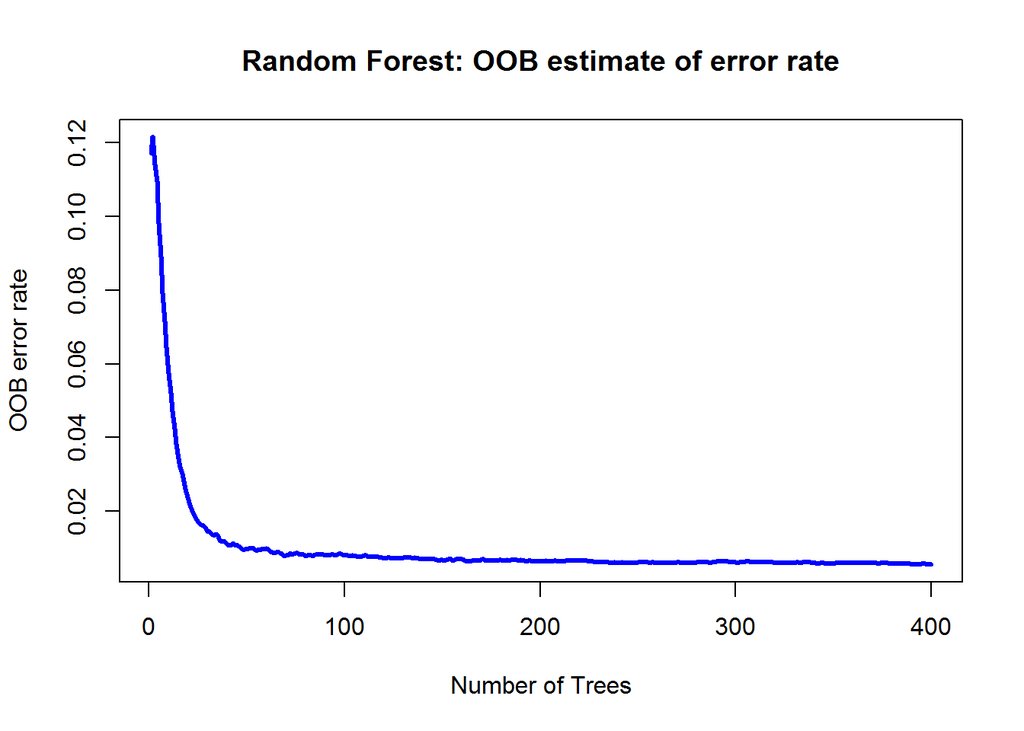

```r
plot(rf$err.rate[,1], type = "l", lwd = 3, col = "blue",
     main = "Random Forest: OOB estimate of error rate",
     xlab = "Number of Trees", ylab = "OOB error rate")
```

From the plot above, it is noted that the error rates stabilises from about 100 trees onwards. To be safe and saving time, we will select 200 trees to use

#### Tuning mtry

We will test the number of mtry to use based on 200 trees

```r
tuneRF(trainSP[,-53],trainSP$classe,ntreeTry = 200)
```

```
## mtry = 7  OOB error = 0.6%
## Searching left ...
## mtry = 4     OOB error = 0.65%
## -0.08536585 0.05
## Searching right ...
## mtry = 14    OOB error = 0.68%
## -0.1341463 0.05
```

```
##        mtry    OOBError
## 4.OOB     4 0.006478853
## 7.OOB     7 0.005969280
## 14.OOB   14 0.006770037
```

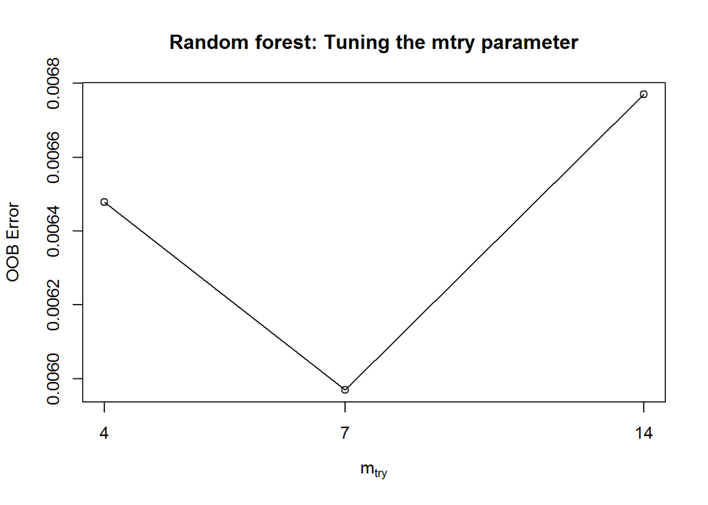

```r
title("Random forest: Tuning the mtry parameter")
```

From the plot showned above, it is noted that mtry at 7 gives the lowest error rate. We will use mtry = 7 for our final model.

#### Important Parameters

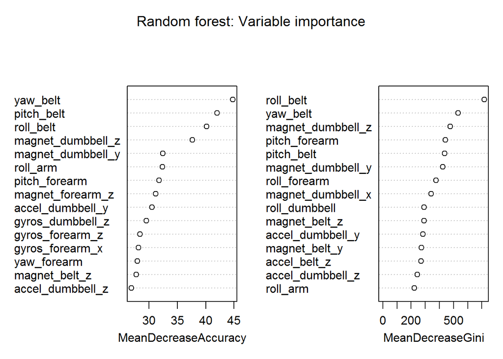

```r
varImpPlot(rf,main = "Random forest: Variable importance",n.var=15)
```

The plot of the important parameters showed the top few parameters which are significant to determining the output. To refine, we can even reduce the parameters to the top ten. However since the amount of time needed to train using the whole dataset, we will not reduce the parameters.

## Final Learning Model

The Final Model will be trained using RandomForest of 200 trees and 7 variables The model will be used to predict the outcome for the predicted file (predictSP)

```r
rf <- randomForest(classe~.,data=trainSP,mtry=7,ntree=200)
confusionMatrix(testSP$classe,predict(rf,testSP))
```

```
## Confusion Matrix and Statistics
##
##           Reference
## Prediction    A    B    C    D    E
##          A 1670    4    0    0    0
##          B    6 1129    4    0    0
##          C    0    6 1017    3    0
##          D    0    0    3  961    0
##          E    0    0    3    3 1076
##
## Overall Statistics
##
##                Accuracy : 0.9946
##                  95% CI : (0.9923, 0.9963)
##     No Information Rate : 0.2848
##     P-Value [Acc > NIR] : < 2.2e-16
##
##                   Kappa : 0.9931
##  Mcnemar's Test P-Value : NA
##
## Statistics by Class:
##
##                      Class: A Class: B Class: C Class: D Class: E
## Sensitivity            0.9964   0.9912   0.9903   0.9938   1.0000
## Specificity            0.9990   0.9979   0.9981   0.9994   0.9988
## Pos Pred Value         0.9976   0.9912   0.9912   0.9969   0.9945
## Neg Pred Value         0.9986   0.9979   0.9979   0.9988   1.0000
## Prevalence             0.2848   0.1935   0.1745   0.1643   0.1828
## Detection Rate         0.2838   0.1918   0.1728   0.1633   0.1828
## Detection Prevalence   0.2845   0.1935   0.1743   0.1638   0.1839
## Balanced Accuracy      0.9977   0.9946   0.9942   0.9966   0.9994
```

```r
predictRES <- predict(rf,predictSP[,-53])
```

The confusionMatrix on the test data showed the accuracy to be about the same as the previous model. With the accuracy of more than 99.4%, Out of Box(OOB) Error is less than 1%. Thus, it is sufficient for prediction.

## Output results to file

The results of the prediction will be output the files by the function below.

```r
pml_write_files = function(x){
    n = length(x)
    for(i in 1:n){
        filename = paste0("problem_id_",i,".txt")
        write.table(x[i],file=filename,quote=FALSE,row.names=FALSE,col.names=FALSE)
    }
}
pml_write_files(predictRES)
```

The output from the function call will be used for submission in the 2nd part of the project exercise.